# Problem Set 6: Regression Discontinuity

Claire Duquennois

*Name:* Tory

Instructions:

- This assignment is an individual assignment. You may discuss your responses in small groups or reach out to a classmate if you are having difficulties with coding but your code and answers must reflect your individual efforts and be written using your own words. Identical assignments will be given a zero grade.
- You must post your code in a private repo on GitHub and invite the TA and I as collaborators.
- You must update your work on GitHub frequently through commits where we can observe which lines you most recently worked on when we click on the repo history. This is done very easily if you are using Git correctly which is part of what we are assessing with this assignment. Make sure you make at least five commits that highlight your most recent changes.

# 1 Empirical Analysis using Data from Manacorda, Miguel, & Vigorito (2011, American Economic Journal: Applied Economics)

This exercise uses data from Manacorda, Miguel, & Vigorito’s paper, “Government Transfers and Political Support,” published in the *American Economic Journal: Applied Economics* in 2011. This paper studies how receipt of a government anti-poverty cash transfer changes how beneficiary households support and view the government.

# 2 Finding the data

The data can be found on Edward Miguel’s faculty website. Download and extract the contents from the `Government_Transfers_replication.zip` file.

# 3 Set up and constructing the data

The original data used in the paper is confidential. The authors instead provide the `reg_panes.dta` data file which is anonymized and created from the original data.

## 3.1 Question: Loading the Packages

Load any R packages you will be using: **Code:**

```r
library(haven)
library(ggplot2)
library(stargazer)
library(dplyr)
library(radiant.data)
library(lfe)
```

## 3.2 Question: Open the `reg_panes.dta` file. To complete this problem set you will need the following variables from this data file:

| Name | Description |
| --- | --- |
| aprobado | Ever received PANES 2005-2007 |
| untracked07 | Untracked in 2007 |
| h_89 | Supports current government 2007 [1 to 3] |
| hv34 | Supports current government 2008 [1 to 3] |
| ind_reest | Predicted Income |
| newtreat | PANES eligibility |
| geo | Geographic locality |
| bl_medad | Mean age |
| lnbl_ytoth_pc | Log per capita income |
| bl_hhsize | Mean household size |
| bl_meduc | Mean education |
| missbl_medad | Missing mean age |
| misslnbl_ytoth_pc | Missing log per capita income |
| missbl_hhsize | Missing mean household size |
| missbl_meduc | Missing mean education |
| sexo | Respondent is female |
| edad | Respondent age |
| aniosed07 | Education in 2007 |
| misssexo | Missing gender |
| missedad | Missing age |
| missaniosed | Missing education |

Drop all other variables. If needed, give the variables you are keeping more intuitive names.

**Code:**

```r
reg_panes <- read_dta("reg_panes.dta")
#View(reg_panes)

reg_panes<-reg_panes%>%select("aprobado", "untracked07", "h_89", "hv34", "ind_reest", "newtreat", "geo", "bl_medad", "lnbl_ytoth_pc", "bl_hhsize", "bl_meduc", "missbl_medad", "misslnbl_ytoth_pc", "missbl_hhsize", "missbl_meduc", "sexo", "edad", "aniosed07",  "misssexo", "missedad", "missaniosed")

colnames(reg_panes)<-c("received", "untracked07", "y_07", "y_08", "pred_inc", "elig", "geo", "mean_age", "log_pc_inc", "mean_hh", "mean_edu", "miss_mean_age", "miss_log_pc_inc", "miss_hh", "miss_mean_edu", "fem", "age", "edu_07", "miss_fem", "miss_age", "miss_edu")
```

## 3.3 **Question: The data as downloaded will require that you clean the variables of interest and construct a new dataset to generate the graphs. Start by generating the following cleaned variable:**

-An indicator for receiving PANES that is NA if a respondent is untracked in 2007

**Code:**

```r
reg_panes$r_adj<-5
reg_panes$r_adj[reg_panes$received==1 & reg_panes$untracked07 == 0]<-1
reg_panes$r_adj[reg_panes$received==0 & reg_panes$untracked07 == 0]<-0
reg_panes$r_adj[reg_panes$untracked07 == 1]<-NA

reg_panes<-rename(reg_panes, rec_track07=r_adj)
```

## 3.4 **Question: We are going to re-scale the variables that indicate support for the current government so that responses range from 0 to 1. To do this, tabulate the current variable to see how it is distributed and then generate a variable that will be NA if it is currently coded as 9, 0 if currently 2, 0.5 if currently 1 and 1 if currently 3. Do this for both the 2007 and 2008 variable.**

```r
tabular<-as.data.frame(matrix(nrow=3098, ncol=0))
tabular$y_07<-reg_panes$y_07
tabular$y_08<-reg_panes$y_08

tabular
```

| y_07 | y_08 |
| --- | --- |
| NA | NA |
| 3 | 1 |
| 3 | 3 |
| 9 | 1 |
| NA | NA |
| 3 | 1 |
| NA | NA |
| 9 | 2 |
| 3 | 3 |
| NA | NA |

[output cut: 3088 more lines]

```r
reg_panes$scaled_y_07<-NA
reg_panes$scaled_y_07[reg_panes$y_07==9]<-NA
reg_panes$scaled_y_07[reg_panes$y_07==2]<-0
reg_panes$scaled_y_07[reg_panes$y_07==1]<-0.5
reg_panes$scaled_y_07[reg_panes$y_07==3]<-1

reg_panes$scaled_y_08<-NA
reg_panes$scaled_y_08[reg_panes$y_08==9]<-NA
reg_panes$scaled_y_08[reg_panes$y_08==2]<-0
reg_panes$scaled_y_08[reg_panes$y_08==1]<-0.5
reg_panes$scaled_y_08[reg_panes$y_08==3]<-1
```

## 3.5 **Question: Generate a variable that is the square of predicted income.**

**Code:**

```r
reg_panes$pred_inc_sq<-reg_panes$pred_inc*reg_panes$pred_inc
```

# 4 We start by reproducing the main figures (2,3,and 4) of the paper as good figures are key to any regression discontinuity paper.

## 4.1 **Question: The data consists of over 3000 observations. How many points are plotted on these figures? How should we interpret the y axis? What does each point below the threshold represent? What does each point above the threshold represent?**

**Answer: There are 45 points on these figures. In figure 2 the y axis is the probability of being treated (getting PANES). In figures 3 and 4 the y-axis is political support for the government (scaled from 0-1).**

## 4.2 **Question: Why is the number of points above the threshold different from the number below?**

**Answer The number of points above the threshold is different from the number below because the authors’ data had approximately twice as many households below the threshold than above, so they put more bins below the threshold so that each bin would have the same number of observations in it.**

## 4.3 **Question: Replicating these figures will require restructuring our data and calculating the values that are plotted. Generate a variable that will indicate the percentile group the observation is in. Note the difference in the number of percentile groups above and below the threshold.**

Note: you may find the `xtile` function in R useful.

**Code:**

```r
reg_panes$percentile<-0
reg_panes$percentile[reg_panes$pred_inc<0]<-xtile(reg_panes$pred_inc[reg_panes$pred_inc<0], 30)
reg_panes$percentile[reg_panes$pred_inc>0]<-xtile(reg_panes$pred_inc[reg_panes$pred_inc>0], 15) + 100
```

## 4.4 **Question: For each of the percentile groups, calculate the mean of each of the variables we will use for plotting: predicted income, receipt of PANES, support for the government in 2007, and support for the government in 2008.**

**Code:**

```r
shaped_data<-reg_panes%>%filter(!is.na(rec_track07) & !is.na(scaled_y_07) & !is.na(scaled_y_08))

shaped_data<-shaped_data%>%dplyr::group_by(percentile)%>%dplyr::summarise(mean_inc=mean(pred_inc), mean_rec_panes=mean(received), mean_gov_sup07=mean(scaled_y_07), mean_gov_sup08=mean(scaled_y_08))

shaped_data
```

| percentile | mean_inc | mean_rec_panes | mean_gov_sup07 | mean_gov_sup08 |
| --- | --- | --- | --- | --- |
| 1 | -0.0196425257 | 1.00000000 | 0.9473684 | 0.9078947 |
| 2 | -0.0189551436 | 1.00000000 | 0.9571429 | 0.9285714 |
| 3 | -0.0182196860 | 1.00000000 | 0.9000000 | 0.7857143 |
| 4 | -0.0176487302 | 1.00000000 | 0.8918919 | 0.8648649 |
| 5 | -0.0168782168 | 1.00000000 | 0.9729730 | 0.9054054 |
| 6 | -0.0161067551 | 1.00000000 | 0.9444444 | 0.8888889 |
| 7 | -0.0155818810 | 1.00000000 | 0.9411765 | 0.8235294 |
| 8 | -0.0150622079 | 1.00000000 | 0.9482759 | 0.8620690 |
| 9 | -0.0144984426 | 1.00000000 | 0.9534884 | 0.8139535 |
| 10 | -0.0138685288 | 1.00000000 | 0.9583333 | 0.8333333 |

[output cut: 35 more lines]

## 4.5 **Question: Replicate figure 2. Make the figure as clear and informative as possible. You may want to create an indicator variable for percentiles above and below the threshold.**

**Code:**

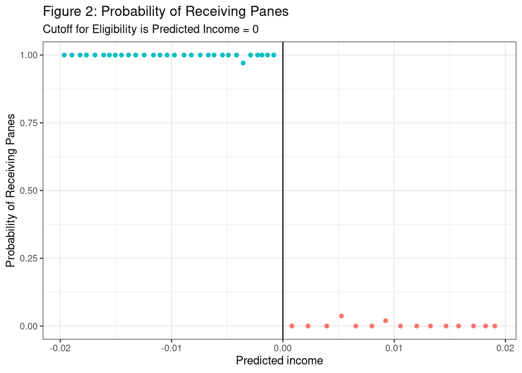

```r
fig2_data<-reg_panes%>%filter(!is.na(rec_track07) & !is.na(scaled_y_07) & !is.na(scaled_y_08))

fig2_data<-fig2_data%>%dplyr::group_by(percentile)%>%dplyr::summarise(mean_inc=mean(pred_inc), mean_rec_panes=mean(rec_track07), mean_gov_sup07=mean(scaled_y_07), mean_gov_sup08=mean(scaled_y_08))

fig2_data$indicator<-0
fig2_data$indicator[fig2_data$mean_inc<0]<-1
#View(fig2_data)
vect<-seq(-.02,.02, by=0.01)



plot<-ggplot(data=fig2_data, aes(x=mean_inc, y=mean_rec_panes, color=factor(indicator))) + geom_point() + geom_vline(xintercept = 0) +theme_bw() + labs(title="Figure 2: Probability of Receiving Panes", subtitle = "Cutoff for Eligibility is Predicted Income = 0", x="Predicted income", y = "Probability of Receiving Panes")  + theme(legend.position="none")

plot
```

## 4.6 **Question: What is the purpose of this figure and what should we take away from it?**

**Answer: We use this figure to check that there actually is a discontinuity in the probability of being treated at the gap. It is the “first stage” of the RD.**

## 4.7 **Question: Replicate figures 3 and 4. Make these figures as clear and informative as possible.**

**Code:**

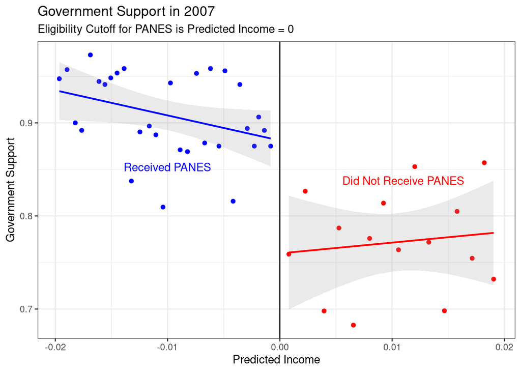

```r
fig3_right<-fig2_data%>%filter(indicator==0)
fig3_left<-fig2_data%>%filter(indicator==1)

fig3 <- ggplot(data = fig3_left, aes(x = mean_inc, y = mean_gov_sup07)) + geom_point(color = "blue", alpha=1) + labs(x = "Predicted Income", y = "Government Support", title = "Government Support in 2007", subtitle = "Eligibility Cutoff for PANES is Predicted Income = 0") + theme_bw() + geom_smooth(data=fig3_left, method = lm, color = "blue", size = .8, alpha = .2, label="All categories") +geom_vline(xintercept = 0)
fig3 <- fig3 + geom_point(data = fig3_right, color="red")  + geom_smooth(data=fig3_right, color="red", method = lm, size = .8, alpha = .2) + annotate(geom="text", x=-.01, y=.8524, label="Received PANES", color="blue") + annotate(geom="text", x=.011, y=.838, label="Did Not Receive PANES", color="red")

fig3
```

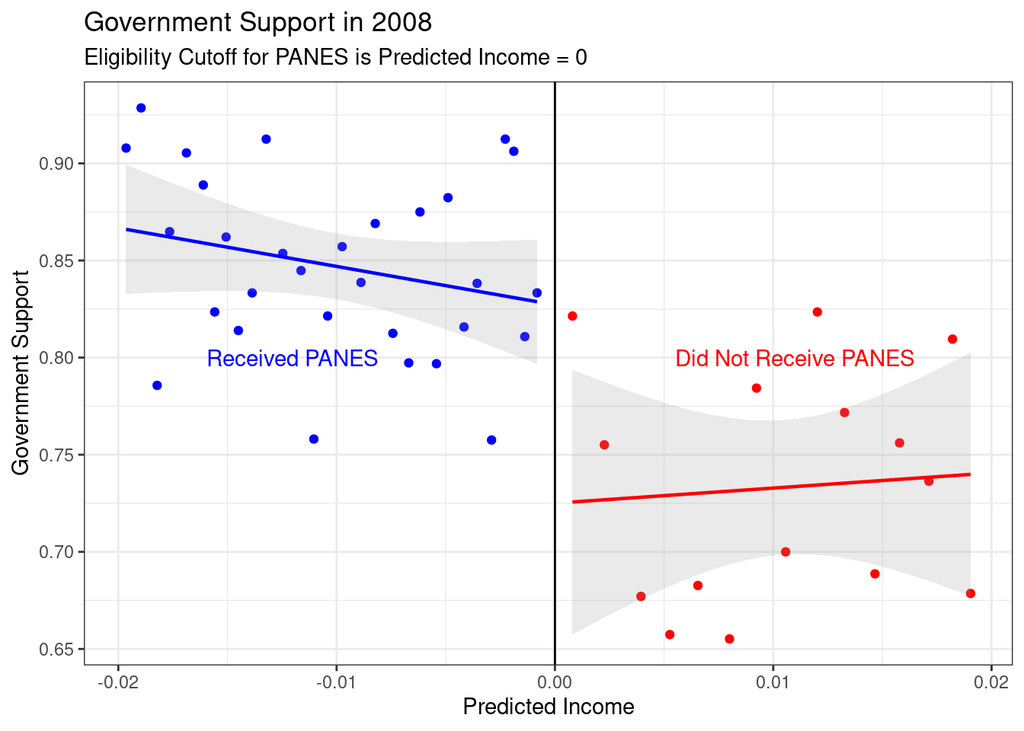

```r
fig4_right<-fig2_data%>%filter(indicator==0)
fig4_left<-fig2_data%>%filter(indicator==1)

fig4 <- ggplot(data = fig4_left, aes(x = mean_inc, y = mean_gov_sup08)) + geom_point(color = "blue", alpha=1) + labs(x = "Predicted Income", y = "Government Support", title = "Government Support in 2008",subtitle = "Eligibility Cutoff for PANES is Predicted Income = 0") + theme_bw() + geom_smooth(data=fig4_left, method = lm, color = "blue", size = .8, alpha = .2, label="All categories")
fig4 <- fig4 + geom_point(data = fig4_right, color="red")  + geom_smooth(data=fig4_right, method = lm, color = "red", size = .8, alpha = .2) + geom_vline(xintercept = 0) + annotate(geom="text", x=-.012, y=.8, label="Received PANES", color="blue")+ annotate(geom="text", x=.011, y=.8, label="Did Not Receive PANES", color="red")

fig4
```

## **Question: Interpret these figures. What should we take away from them?**

**Answer: These results show a clear gap in government support among those who received panes transfers and those who do not. We should take away from these results that there is likely a causal relationship between the receipt of government transfers and support for the government, at least for people who fall very close to the support cutoff line.**

## 4.8 **Question: Replicate the results of the three regressions estimated in the first column of table 1. Present your results in a table. Interpret the coefficients.**

**Code:**

```r
row1col1<-felm(received~elig|0|0|pred_inc, reg_panes)
row2col1<-felm(scaled_y_07~elig|0|0|pred_inc, reg_panes)
row3col1<-felm(scaled_y_08~elig|0|0|pred_inc, reg_panes)

stargazer(row1col1, row2col1, row3col1,type="html", se=list(row1col1$rse, row2col1$rse, row3col1$rse))
```

|  | *Dependent variable:* |  |  |
| --- | --- | --- | --- |
|  | received | scaled_y_07 | scaled_y_08 |
|  | (1) | (2) | (3) |
| elig | 0.995*** | 0.129*** | 0.118*** |
|  | (0.002) | (0.013) | (0.015) |
| Constant | 0.003** | 0.772*** | 0.728*** |
|  | (0.002) | (0.011) | (0.012) |
| Observations | 3,098 | 2,089 | 1,948 |
| R<sup>2</sup> | 0.989 | 0.050 | 0.034 |
| Adjusted R<sup>2</sup> | 0.989 | 0.049 | 0.033 |
| Residual Std. Error | 0.051 (df = 3096) | 0.280 (df = 2087) | 0.313 (df = 1946) |
| *Note:* | p<0.1; p<0.05; p<0.01 |  |  |

**Answer: The coefficient on received means that being eligible for PANES means a 99.5% probability of receiving PANES. The coefficient on scaled_y_07 means that being eligible for PANES is associated with a 0.129 point higher approval rating. Given that the coefficient is highly significant and that approval ratings go from 0-1, the 0.129 is a proportionately large number. The coefficient on scaled_y_08 means that being eligible for PANES is associated with a 0.118 unit increase of government approval rating in 2008. This number is highly significant and a 11.8% of the total possible rating (1).**

## 4.9 **Question: Write down the specifications used in row 2 of columns 1,2 and 3 of table 1.**

**Answer:** #ROW 2 COLUMN 1
$$Y_isupport07 = \beta_0+ \beta eligibility +
e_i$$

#ROW 2 COLUMN 2

$$Y_isupport07 = \beta_0+ \beta
eligibility + \beta predincome+ \beta predincome*eligibility +
e_i$$

#ROW 2 COLUMN 3

$$Y_isupport07 = \beta_0+ \beta
eligibility + \beta predincome+ \beta predincome*eligibility+ \beta
predincome^2+ \beta predincome^2*eligibility + e_i$$

## 4.10 **Question: Replicate all of the results reported in row 2 of Table 1. Explain the difference between these specifications and interpret their coefficients.**

Hint: the variables listed in the table above after newtreat are the controls you will want to include.

**Code:**

```r
row2col1<-felm(scaled_y_07~elig|0|0|pred_inc, reg_panes)

row2col2<-felm(scaled_y_07~elig+pred_inc+pred_inc*elig|0|0|pred_inc, reg_panes)

row2col3<-felm(scaled_y_07~elig+pred_inc+pred_inc*elig+pred_inc_sq+pred_inc_sq*elig|0|0|pred_inc, reg_panes)

row2col4<-felm(scaled_y_07~elig+geo+mean_age+log_pc_inc+mean_hh+mean_edu + miss_mean_edu+miss_mean_age+miss_log_pc_inc+fem+age+edu_07+miss_fem+miss_edu|0|0|pred_inc, reg_panes)

row2col5<-felm(scaled_y_07~elig+pred_inc+pred_inc*elig+geo+mean_age+log_pc_inc+mean_hh+mean_edu + miss_mean_edu+miss_mean_age++miss_hh+miss_log_pc_inc+fem+age+edu_07+miss_fem+miss_edu|0|0|pred_inc, reg_panes)

row2col6<-felm(scaled_y_07~elig+pred_inc+pred_inc*elig+pred_inc_sq+pred_inc_sq*elig+geo+mean_age+log_pc_inc+mean_hh+mean_edu + miss_mean_edu+miss_mean_age+miss_log_pc_inc+fem+age+edu_07+miss_fem+miss_edu+miss_hh|0|0|pred_inc, reg_panes)

row2col5<-felm(scaled_y_07~elig+pred_inc+pred_inc*elig+geo+mean_age+log_pc_inc+mean_hh+mean_edu+ miss_mean_edu+miss_mean_age+miss_log_pc_inc+fem+age+edu_07+miss_fem+miss_edu+miss_hh|0|0|pred_inc, reg_panes)


stargazer(row2col1, row2col2, row2col3,row2col4,row2col5,row2col6, type="html", se=list(row2col1$rse, row2col2$rse, row2col3$rse, row2col4$rse,row2col5$rse,row2col6$rse))
```

|  | *Dependent variable:* |  |  |  |  |  |
| --- | --- | --- | --- | --- | --- | --- |
|  | scaled_y_07 |  |  |  |  |  |
|  | (1) | (2) | (3) | (4) | (5) | (6) |
| elig | 0.129*** | 0.110*** | 0.130*** | 0.132*** | 0.108*** | 0.133*** |
|  | (0.013) | (0.026) | (0.040) | (0.013) | (0.026) | (0.040) |
| pred_inc |  | -0.011 | 0.812 |  | -0.275 | 0.582 |
|  |  | (1.938) | (7.518) |  | (1.939) | (7.527) |
| pred_inc_sq |  |  | -40.457 |  |  | -41.873 |
|  |  |  | (367.102) |  |  | (366.520) |
| elig:pred_inc |  | -1.916 | 2.377 |  | -1.742 | 3.718 |
|  |  | (2.244) | (9.169) |  | (2.243) | (9.218) |
| elig:pred_inc_sq |  |  | 292.215 |  |  | 352.682 |
|  |  |  | (441.420) |  |  | (440.352) |
| geo |  |  |  | 0.001 | 0.001 | 0.001 |
|  |  |  |  | (0.001) | (0.001) | (0.001) |
| mean_age |  |  |  | -0.00003 | -0.00001 | 0.00002 |
|  |  |  |  | (0.001) | (0.001) | (0.001) |
| log_pc_inc |  |  |  | -0.00000** | -0.00000** | -0.00000** |
|  |  |  |  | (0.00000) | (0.00000) | (0.00000) |
| mean_hh |  |  |  | -0.002 | -0.003 | -0.002 |
|  |  |  |  | (0.004) | (0.004) | (0.004) |
| mean_edu |  |  |  | -0.00000 | -0.00000 | -0.00000 |
|  |  |  |  | (0.00000) | (0.00000) | (0.00000) |
| miss_mean_edu |  |  |  |  |  |  |
|  |  |  |  | (0.000) | (0.000) | (0.000) |
| miss_mean_age |  |  |  |  |  |  |
|  |  |  |  | (0.000) | (0.000) | (0.000) |
| miss_log_pc_inc |  |  |  |  |  |  |
|  |  |  |  | (0.000) | (0.000) | (0.000) |
| fem |  |  |  | 0.00000*** | 0.00000*** | 0.00000*** |
|  |  |  |  | (0.00000) | (0.00000) | (0.00000) |
| age |  |  |  | 0.00000*** | 0.00000*** | 0.00000*** |
|  |  |  |  | (0.00000) | (0.00000) | (0.00000) |
| edu_07 |  |  |  | -0.00000 | -0.00000 | -0.00000 |
|  |  |  |  | (0.00000) | (0.00000) | (0.00000) |
| miss_fem |  |  |  |  |  |  |
|  |  |  |  | (0.000) | (0.000) | (0.000) |
| miss_edu |  |  |  |  |  |  |
|  |  |  |  | (0.000) | (0.000) | (0.000) |
| miss_hh |  |  |  |  |  |  |
|  |  |  |  |  | (0.000) | (0.000) |
| Constant | 0.772*** | 0.772*** | 0.769*** | 0.776*** | 0.779*** | 0.775*** |
|  | (0.011) | (0.022) | (0.032) | (0.029) | (0.035) | (0.043) |
| Observations | 2,089 | 2,089 | 2,089 | 2,089 | 2,089 | 2,089 |
| R<sup>2</sup> | 0.050 | 0.051 | 0.051 | 0.055 | 0.056 | 0.056 |
| Adjusted R<sup>2</sup> | 0.049 | 0.049 | 0.049 | 0.051 | 0.051 | 0.050 |
| Residual Std. Error | 0.280 (df = 2087) | 0.280 (df = 2085) | 0.280 (df = 2083) | 0.280 (df = 2079) | 0.280 (df = 2077) | 0.280 (df = 2075) |
| *Note:* | p<0.1; p<0.05; p<0.01 |  |  |  |  |  |

**Interpret the coefficients: All of the coefficients are between 0.1 and 0.15. Because the support for the government variables ranges from 0 to 1 this means that the coefficients are estimating that being eligible for PANES is correlated with an increase in support for the government in 2007 by about 10-15% for those near the eligibility cutoff.**

## 4.11 **Question: What is the point of including all of these specifications?**

**Answer: These specifications prove the robustness of the results. Because the eligibility coefficient remains highly significant throughout all of the specifications we know that the authors didn’t just pick a regression model that spit out significant values.**

## 4.12 **Question: Using the coefficients estimated above, write out the function you would use to predict the probability a household supports the current government based on their predicted income score:**

**a) If they are eligible for the transfer using the results from column 1.**

p(support) = 0.129 + 0.772 = 0.901

**b) If they are not eligible for the transfer using the results from column 1.**

p(support) = 0.772

**c) If they are eligible for the transfer using the results from column 2.**

p(support) = 0.110 - 0.011(predicted income) - 1.916*predicted income + 0.772 = 0.110 - 1.927(predicted income) + 0.772

**d) If they are not eligible for the transfer using the results from column 2.**

p(support) = .772 - 0.011(predicted income)

**e) If they are eligible for the transfer using the results from column 3.**

p(support) = 0.769 + 0.130 + 0.812*predicted income - 40.457(predicted income^2) + 2.377(predicted income) + 292.215(predicted income^2) = 0.899 + 3.189(predicted income) + 251.758(predicted income^2)

**f) If they are not eligible for the transfer using the results from column 3.**

p(support) = 0.769 + 0.812(predicted income) - 40.457(predicted income^2)

## 4.13 **Question: How narrow is the “bandwidth” used by the authors. Why does this matter? Check that the results are robust to a narrower bandwidth.**

**Code:**

```r
reg_panes_narrow<-reg_panes%>%filter(pred_inc<=0.01 | pred_inc>=-.01)



row2col1<-felm(scaled_y_07~elig|0|0|pred_inc, reg_panes_narrow)

row2col2<-felm(scaled_y_07~elig+pred_inc+pred_inc*elig|0|0|pred_inc, reg_panes_narrow)

row2col3<-felm(scaled_y_07~elig+pred_inc+pred_inc*elig+pred_inc_sq+pred_inc_sq*elig|0|0|pred_inc, reg_panes_narrow)

row2col4<-felm(scaled_y_07~elig+geo+mean_age+log_pc_inc+mean_hh+mean_edu + miss_mean_edu+miss_mean_age+miss_log_pc_inc+fem+age+edu_07+miss_fem+miss_edu|0|0|pred_inc, reg_panes_narrow)

row2col5<-felm(scaled_y_07~elig+pred_inc+pred_inc*elig+geo+mean_age+log_pc_inc+mean_hh+mean_edu + miss_mean_edu+miss_mean_age++miss_hh+miss_log_pc_inc+fem+age+edu_07+miss_fem+miss_edu|0|0|pred_inc, reg_panes_narrow)

row2col6<-felm(scaled_y_07~elig+pred_inc+pred_inc*elig+pred_inc_sq+pred_inc_sq*elig+geo+mean_age+log_pc_inc+mean_hh+mean_edu + miss_mean_edu+miss_mean_age+miss_log_pc_inc+fem+age+edu_07+miss_fem+miss_edu+miss_hh|0|0|pred_inc, reg_panes_narrow)

row2col5<-felm(scaled_y_07~elig+pred_inc+pred_inc*elig+geo+mean_age+log_pc_inc+mean_hh+mean_edu+ miss_mean_edu+miss_mean_age+miss_log_pc_inc+fem+age+edu_07+miss_fem+miss_edu+miss_hh|0|0|pred_inc, reg_panes_narrow)


stargazer(row2col1, row2col2, row2col3,row2col4,row2col5,row2col6, type="html", se=list(row2col1$rse, row2col2$rse, row2col3$rse, row2col4$rse,row2col5$rse,row2col6$rse))
```

|  | *Dependent variable:* |  |  |  |  |  |
| --- | --- | --- | --- | --- | --- | --- |
|  | scaled_y_07 |  |  |  |  |  |
|  | (1) | (2) | (3) | (4) | (5) | (6) |
| elig | 0.129*** | 0.110*** | 0.130*** | 0.132*** | 0.108*** | 0.133*** |
|  | (0.013) | (0.026) | (0.040) | (0.013) | (0.026) | (0.040) |
| pred_inc |  | -0.011 | 0.812 |  | -0.275 | 0.582 |
|  |  | (1.938) | (7.518) |  | (1.939) | (7.527) |
| pred_inc_sq |  |  | -40.457 |  |  | -41.873 |
|  |  |  | (367.102) |  |  | (366.520) |
| elig:pred_inc |  | -1.916 | 2.377 |  | -1.742 | 3.718 |
|  |  | (2.244) | (9.169) |  | (2.243) | (9.218) |
| elig:pred_inc_sq |  |  | 292.215 |  |  | 352.682 |
|  |  |  | (441.420) |  |  | (440.352) |
| geo |  |  |  | 0.001 | 0.001 | 0.001 |
|  |  |  |  | (0.001) | (0.001) | (0.001) |
| mean_age |  |  |  | -0.00003 | -0.00001 | 0.00002 |
|  |  |  |  | (0.001) | (0.001) | (0.001) |
| log_pc_inc |  |  |  | -0.00000** | -0.00000** | -0.00000** |
|  |  |  |  | (0.00000) | (0.00000) | (0.00000) |
| mean_hh |  |  |  | -0.002 | -0.003 | -0.002 |
|  |  |  |  | (0.004) | (0.004) | (0.004) |
| mean_edu |  |  |  | -0.00000 | -0.00000 | -0.00000 |
|  |  |  |  | (0.00000) | (0.00000) | (0.00000) |
| miss_mean_edu |  |  |  |  |  |  |
|  |  |  |  | (0.000) | (0.000) | (0.000) |
| miss_mean_age |  |  |  |  |  |  |
|  |  |  |  | (0.000) | (0.000) | (0.000) |
| miss_log_pc_inc |  |  |  |  |  |  |
|  |  |  |  | (0.000) | (0.000) | (0.000) |
| fem |  |  |  | 0.00000*** | 0.00000*** | 0.00000*** |
|  |  |  |  | (0.00000) | (0.00000) | (0.00000) |
| age |  |  |  | 0.00000*** | 0.00000*** | 0.00000*** |
|  |  |  |  | (0.00000) | (0.00000) | (0.00000) |
| edu_07 |  |  |  | -0.00000 | -0.00000 | -0.00000 |
|  |  |  |  | (0.00000) | (0.00000) | (0.00000) |
| miss_fem |  |  |  |  |  |  |
|  |  |  |  | (0.000) | (0.000) | (0.000) |
| miss_edu |  |  |  |  |  |  |
|  |  |  |  | (0.000) | (0.000) | (0.000) |
| miss_hh |  |  |  |  |  |  |
|  |  |  |  |  | (0.000) | (0.000) |
| Constant | 0.772*** | 0.772*** | 0.769*** | 0.776*** | 0.779*** | 0.775*** |
|  | (0.011) | (0.022) | (0.032) | (0.029) | (0.035) | (0.043) |
| Observations | 2,089 | 2,089 | 2,089 | 2,089 | 2,089 | 2,089 |
| R<sup>2</sup> | 0.050 | 0.051 | 0.051 | 0.055 | 0.056 | 0.056 |
| Adjusted R<sup>2</sup> | 0.049 | 0.049 | 0.049 | 0.051 | 0.051 | 0.050 |
| Residual Std. Error | 0.280 (df = 2087) | 0.280 (df = 2085) | 0.280 (df = 2083) | 0.280 (df = 2079) | 0.280 (df = 2077) | 0.280 (df = 2075) |
| *Note:* | p<0.1; p<0.05; p<0.01 |  |  |  |  |  |

## 4.14 **Question: The authors attribute these effects to the causal effect of receiving the government transfers. What is the implied assumption behind this interpretation?**

**Answer: The implied assumption behind the causal interpretation is that eligibility right around the threshold is as good as random. This means that no one is “gaming the system” to end up just underneath the eligibility line, which would enter selection bias into the results and would mean we could no longer interpret a causal relationship.**

## 4.15 **Question: What evidence do they provide to support this assumption?**

**Answer: The evidence to support this assumption is that the people filling out the surveys for the PANES eligibility didn’t know how the eligibility was being calculated, which means they wouldn’t have been able to game the system. Furthermore, the poverty score and the assignment cutoff were not even determined until after the surveys had been taken, which means it is impossible that participants knew well enough to lie ahead of time.**

## 4.16 **Question: Was this threshold eligibility score specifically designed for this particular program? Why does this matter?**

**Answer: This threshold eligibility score was specifically designed for this particular program. This matters because if the same threshold was also being used for another program than the effects of receiving transfers from that program would also be coming in to these results. If that were the case, it would be impossible to tell what of the effects were because of PANES and what were because of the other programs, which means you can no longer determine a causal relationship.**

# 5 Submission instructions:

1. Make sure the final version of your assignment is uploaded on GitHub in both html and Rmarkdown format.